# BRITISH AIRWAYS

## A web scraping and data analysis project of customer review data to uncover findings for British Airways

### Project by: Imen Cherif

Note: This notebook is a part of my first task as a virtual intern within British Airways. This task is focused on scraping and collecting customer feedback and reviewing data from a third-party source (Skytrax) and analysing this data to later present my insights.

### Step 1: Web Scraping

The first thing to do is to scrape review data from the web using a website called Skytrax. The reviews collected are specifically about the airline itself.

```python
import requests
from bs4 import BeautifulSoup
import pandas as pd
```

```python
base_url = "https://www.airlinequality.com/airline-reviews/british-airways"
pages = 10
page_size = 100

reviews = []

# for i in range(1, pages + 1):
for i in range(1, pages + 1):

    print(f"Scraping page {i}")

    # Create URL to collect links from paginated data
    url = f"{base_url}/page/{i}/?sortby=post_date%3ADesc&pagesize={page_size}"

    # Collect HTML data from this page
    response = requests.get(url)

    # Parse content
    content = response.content
    parsed_content = BeautifulSoup(content, 'html.parser')
    for para in parsed_content.find_all("div", {"class": "text_content"}):
        reviews.append(para.get_text())

    print(f"   ---> {len(reviews)} total reviews")
```

```
Scraping page 1
   ---> 100 total reviews
Scraping page 2
   ---> 200 total reviews
Scraping page 3
   ---> 300 total reviews
Scraping page 4
   ---> 400 total reviews
Scraping page 5
   ---> 500 total reviews
Scraping page 6
   ---> 600 total reviews
Scraping page 7
   ---> 700 total reviews
Scraping page 8
   ---> 800 total reviews
Scraping page 9
   ---> 900 total reviews
Scraping page 10
   ---> 1000 total reviews
```

```python
df = pd.DataFrame()
df["reviews"] = reviews
df.head()
```

|  | reviews |
| --- | --- |
| 0 | Not Verified \| Generally poor. Sent to gate o... |
| 1 | Not Verified \| BA changed our prepaid seats a... |
| 2 | Not Verified \| Flew from London Heathrow to M... |
| 3 | Not Verified \| I was meant to fly in January t... |
| 4 | ✅ Trip Verified \| We have flown repeatedly wi... |

```python
df.to_csv("BA_reviews.csv")
```

The dataset is now ready and stored in a csv file. The loops above collected 1000 reviews by iterating through the paginated pages on the website.

### Step 2: Data Cleaning:

The next thing that we should do is toclean this data to remove any unnecessary text from each of the rows. For example, "✅ Trip Verified" can be removed from each row if it exists, as it's not relevant to what we want to investigate. Once we remove all verified trips, we can also remove the mention "Not verified" not to affect our analysis of the data.

```python
import re
```

```python
df = pd.read_csv('BA_reviews.csv')
mask = df['reviews'].str.contains('✅ Trip Verified')
df = df.drop(df[mask].index)
df.to_csv('cleaned_dataset.csv', index=False)
```

```python
df = pd.read_csv('cleaned_dataset.csv')
regex = r"Not Verified \| "
df['reviews'] = df['reviews'].apply(lambda x: re.sub(regex, '', x))
df.to_csv('data.csv', index=False)
```

Now that the dataset is cleaned, we move to the analysis process. During the next steps, three major axes will be focused on: topic modeling, sentiment analysis, and wordclouds.

### Step 3: Text processing

```python
import nltk
from nltk.corpus import stopwords
nltk.download('stopwords')
nltk.download('wordnet')
nltk.download('omw-1.4')
```

```
True
```

```python
def text_preprocessing(text):

    # Converting words to lower case
    text = text.lower()

    # Formatting words and removing unwanted characters
    text = re.sub(r'https?:\/\/.*[\r\n]*', '', text, flags=re.MULTILINE)
    text = re.sub(r'\<a href', ' ', text)
    text = re.sub(r'&amp;', '', text)
    text = re.sub(r'[_"\-;%()|+&=*%.,!?:#$@\[\]/]', ' ', text)
    text = re.sub(r'<br />', ' ', text)
    text = re.sub(r'\'', ' ', text)

    # Tokenizing each word
    text = nltk.WordPunctTokenizer().tokenize(text)

    # Lemmatizing each word
    text = [nltk.stem.WordNetLemmatizer().lemmatize(token, pos='v') for token in text if len(token)>1]
    return text

    # Removing stopwords
    stop_words = set(stopwords.words('english'))
    filtered_txt = [t for t in text if t.lower() not in stop_words]
    filtered_text = ' '.join(filtered_txt)
    text=filtered_text

df['processed_reviews'] = df['reviews'].apply(text_preprocessing)
df.head()
```

|  | Unnamed: 0 | reviews | processed_reviews |
| --- | --- | --- | --- |
| 0 | 0 | Generally poor. Sent to gate on time, sat may... | [generally, poor, send, to, gate, on, time, si... |
| 1 | 1 | BA changed our prepaid seats at the last minu... | [ba, change, our, prepay, seat, at, the, last,... |
| 2 | 2 | Flew from London Heathrow to Marrakech. BA ch... | [fly, from, london, heathrow, to, marrakech, b... |
| 3 | 3 | I was meant to fly in January to Algeria. I pa... | [be, mean, to, fly, in, january, to, algeria, ... |
| 4 | 9 | Booked a flight return flight between London ... | [book, flight, return, flight, between, london... |

### Step 4: Topic Modeling using the Latent Dirichlet Allocation (LDA)

```python
import gensim
from gensim import corpora, models

# Select the column you want to perform topic modeling on
texts = df['processed_reviews']

# Create a dictionary from the tokens
dictionary = corpora.Dictionary(texts)

# Convert the tokens to a bag-of-words corpus
corpus = [dictionary.doc2bow(text) for text in texts]

# Train an LDA model with 10 topics
lda_model = models.ldamodel.LdaModel(corpus=corpus, num_topics=10, id2word=dictionary, passes=10)

topic_names = []
for i in range(10):
    top_words = [w for w, _ in lda_model.show_topic(i, topn=5)]
    topic_names.append('Topic {}: {}'.format(i, ', '.join(top_words)))

# Print the topics and their associated words
for i, topic in enumerate(lda_model.print_topics(-1)):
    print(topic_names[i])
    print('Words:', topic[1], '\n')
```

```
Topic 0: at, of, passenger, security, late
Words: 0.015*"at" + 0.012*"of" + 0.007*"passenger" + 0.006*"security" + 0.005*"late" + 0.005*"load" + 0.005*"ahead" + 0.005*"seat" + 0.005*"apart" + 0.005*"20"

Topic 1: the, be, to, for, and
Words: 0.001*"the" + 0.001*"be" + 0.001*"to" + 0.001*"for" + 0.001*"and" + 0.001*"have" + 0.000*"in" + 0.000*"they" + 0.000*"flight" + 0.000*"we"

Topic 2: the, be, and, of, on
Words: 0.039*"the" + 0.034*"be" + 0.015*"and" + 0.014*"of" + 0.012*"on" + 0.011*"with" + 0.011*"ba" + 0.011*"but" + 0.010*"service" + 0.009*"to"

Topic 3: be, to, the, and, flight
Words: 0.038*"be" + 0.035*"to" + 0.027*"the" + 0.024*"and" + 0.019*"flight" + 0.016*"have" + 0.011*"for" + 0.011*"in" + 0.011*"no" + 0.011*"with"

Topic 4: the, be, to, and, have
Words: 0.050*"the" + 0.049*"be" + 0.038*"to" + 0.031*"and" + 0.016*"have" + 0.015*"flight" + 0.015*"in" + 0.014*"of" + 0.014*"on" + 0.013*"for"

Topic 5: and, to, be, the, for
Words: 0.037*"and" + 0.035*"to" + 0.025*"be" + 0.021*"the" + 0.015*"for" + 0.014*"we" + 0.013*"have" + 0.012*"seat" + 0.012*"they" + 0.012*"ba"

Topic 6: headache, theirs, okay, cram, vancouver
Words: 0.004*"headache" + 0.004*"theirs" + 0.004*"okay" + 0.004*"cram" + 0.003*"vancouver" + 0.003*"reasonable" + 0.003*"upgrade" + 0.002*"shame" + 0.002*"november" + 0.001*"felt"

Topic 7: min, dentist, decorate, personality, devoid
Words: 0.004*"min" + 0.004*"dentist" + 0.004*"decorate" + 0.004*"personality" + 0.004*"devoid" + 0.004*"badly" + 0.004*"joy" + 0.004*"seriously" + 0.004*"fizz" + 0.004*"terribly"

Topic 8: the, to, and, in, they
Words: 0.001*"the" + 0.001*"to" + 0.000*"and" + 0.000*"in" + 0.000*"they" + 0.000*"be" + 0.000*"have" + 0.000*"for" + 0.000*"on" + 0.000*"of"

Topic 9: be, to, the, and, in
Words: 0.050*"be" + 0.045*"to" + 0.033*"the" + 0.024*"and" + 0.014*"in" + 0.013*"have" + 0.012*"they" + 0.011*"my" + 0.010*"flight" + 0.009*"for"
```

### Step 5: Generating a wordcloud

```python
import matplotlib.pyplot as plt
from wordcloud import WordCloud
```

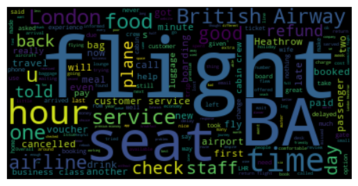

```python
text = ' '.join(df['reviews'].tolist())

# Create a wordcloud object
wordcloud = WordCloud().generate(text)

# Plot the wordcloud
plt.imshow(wordcloud, interpolation='bilinear')
plt.axis("off")
plt.show()
```

### Step 6: Sentiment Analysis of the Customer Reviews

```
Positive Feedback    123
Negative Feedback     58
Neutral Feedback       1
Name: sentiment, dtype: int64
```

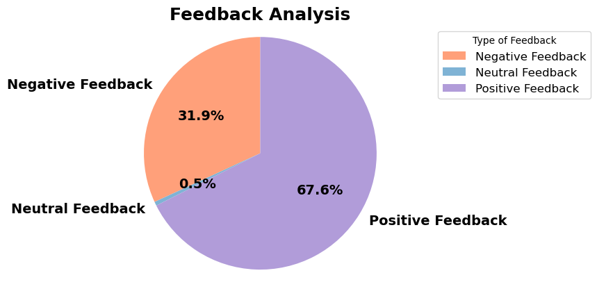

```python
from textblob import TextBlob

# Create a function to apply TextBlob sentiment analysis to each row of the dataframe
def sentiment_analysis(text):
    blob = TextBlob(text)
    sentiment_score = blob.sentiment.polarity
    if sentiment_score > 0:
        return 'Positive Feedback'
    elif sentiment_score < 0:
        return 'Negative Feedback'
    else:
        return 'Neutral Feedback'

# Apply the sentiment_analysis function to each row of the dataframe
df['sentiment'] = df['reviews'].apply(sentiment_analysis)
sentiment_counts = df['sentiment'].value_counts()
print(sentiment_counts)


import matplotlib.pyplot as plt

grouped_data = df.groupby('sentiment').size().reset_index(name='counts')

colors = ['#ffa07a', '#7fb3d5', '#b19cd9', '#77dd77', '#f0e68c']
plt.pie(grouped_data['counts'], labels=grouped_data['sentiment'], colors=colors,
        autopct='%1.1f%%', startangle=90, textprops={'fontsize': 14, 'fontweight': 'bold'})
plt.title('Feedback Analysis', fontsize=18, fontweight='bold')

plt.legend(title='Type of Feedback', loc='best', bbox_to_anchor=(1, 1), fontsize=12)

plt.axis('equal')
plt.show()
```

### Interpretation of the Results:

After scrapping the data, cleaning, and processing it, we conclude that out of the reviews that are not yet validated, almost 68% are positive feedback about the flight experiences of the customers with British Airways. Only one customer had a neutral review, while the rest faced problems with their flights. The wordcloud shows us that the most recurrent words are, as one would expect, "flight" and "BA" referring to British Airways. We can also notice a high frequency of appearance of the words: "seat", "time","hour", "service", "food" which gives us an idea about possible reasons of the customers' dissatisfaction. As a matter of fact, we can think of flight delays as a major reason behind the clients' negative feedback. In terms of locations mentioned, the most obvious ones are "London" and "Heathrow" which can easily be anticipated since the greatest activity of the company is in Britain.

## Conclusion:

Now that the analysis of the customers' reviews is done, we can move to the second task! You can find the next steps in the following notebook.

-Imen Cherif